# PageRank2

Abhinav Nigam

Sunday 05 October 2014

Consider three webpages with the links as below.

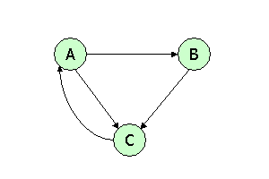

We are going to compute PageRank using Google’s formulation based on Adjacency Matrix formation followed by power iteration till the values converge. We are also going to counter the problem of *dead ends* and *spider-traps* by using teleports with a $\beta$ value of 0.85.

**Adjacency Matrix**  
For finding the adjacency matrix, lets consider that there are *N* pages and page *j* has $\sf{d_{j}}$ outlinks. The matrix is then defined as  
$\sf{M_{ij}} = \frac{1}{|\sf{d_{j}}|}, when \space j\rightarrow i$ $\sf{M_{ij}} = 0, when \space j\not\rightarrow i$

Considering the provided page diagram links, page A has 1 link each to B and C, page B has 1 link to C and page C has 1 link to A. Thus, our adjacency matrix can be written as: $M = \left( \begin{array}{ccc} 0 & 0 & 1 \\ 1/2 & 0 & 0 \\ 1/2 & 1 & 0 \end{array} \right)\$

```r
# In R, The matrix content is filled along the columns by default, this behavior can be changed by toggling the inrow flag
M = matrix(c(0,0.5,0.5,0,0,1,1,0,0), nrow=3, ncol=3)
```

Lets also define the identity matrix that we will use, to consider random jumps scenario in order to deal with *dead end*. This can be written as: $I = \left( \begin{array}{ccc} 1/3 \\ 1/3 \\ 1/3 \end{array} \right)\$

```r
I = matrix(c(1/3,1/3,1/3), nrow=3, ncol=1)
```

We know that the page rank matrix can then be defined as $A = \beta M + \frac{(1-\beta)}{N}I$

```r
B = 0.85
N = 3
```

We can define initial set of r-vector as well. Remember that this set can take any values, as our eventual goal is to make them converge to specific values through power iteration.

$V = \left( \begin{array}{ccc} 1 \\ 1 \\ 1 \end{array} \right)\$

```r
# We are defining V as a matrix to simplify calculations in R
V = matrix(c(1,1,1), nrow=3, ncol=1)
```

Now, all we have to do is recursively calculate the value of V until it converges

```r
repeat{
  Vold = V
  V = ((M*B) %*% V) + c(((1-B)/N)*I)
  if (all(Vold == V)){
    break
  }
}

V
```

```
##        [,1]
## [1,] 0.1293
## [2,] 0.0716
## [3,] 0.1325
```